# Question 1: (Visualization)

### Checking each country's precipitation

```python
country_2025_counts = (
    daily_parsed
    .filter(
        (col("ELEMENT") == "PRCP") &
        (col("DATE").startswith("2025"))
    )
    .join(
        stations.select("ID", "COUNTRY_NAME"),
        on="ID",
        how="inner"
    )
    .groupBy("COUNTRY_NAME")
    .count()
    .orderBy(col("count").asc())
)

country_2025_counts.show(30, truncate=False)
```

```
[Stage 103:====================================================>(107 + 1) / 108]
```

```
+----------------------------------+-----+
|COUNTRY_NAME                      |count|
+----------------------------------+-----+
|Liberia                           |1    |
|Gambia, The                       |2    |
|Lebanon                           |2    |
|Angola                            |3    |
|Azerbaijan                        |3    |
|Zambia                            |4    |
|Kazakhstan                        |4    |
|Cape Verde                        |9    |
|Korea, South                      |10   |
|Saint Pierre and Miquelon [France]|13   |
|Wallis and Futuna [France]        |13   |
|French Guiana [France]            |14   |
|Reunion [France]                  |22   |
|Mayotte [France]                  |23   |
|Bahrain                           |26   |
|Egypt                             |27   |
|Congo (Kinshasa)                  |27   |
|Cambodia                          |33   |
|Ecuador                           |45   |
|Saudi Arabia                      |52   |
|Israel                            |54   |
|Venezuela                         |54   |
|Jordan                            |55   |
|Qatar                             |61   |
|El Salvador                       |62   |
|Malawi                            |67   |
|Nigeria                           |77   |
|Libya                             |83   |
|Botswana                          |99   |
|Rwanda                            |106  |
+----------------------------------+-----+
only showing top 30 rows
```

**One important methodological point**

We should be precise about what our current AVG_DAILY_RAINFALL represents.

Our calculation is effectively:

```
all PRCP observations
        ↓
group by YEAR + COUNTRY
        ↓
average VALUE
```

Therefore, it is an average of reported PRCP observations, not necessarily an average of one daily rainfall value per calendar day. That's important because countries with lots of stations/reporting days contribute many observations, while countries like Liberia contribute only one. We should not change the Q2(a) result now, because that's the result we've already generated and saved. But for Q2(b), we absolutely need to acknowledge this limitation when discussing the outlier and the choropleth.

### Checking how many countries have extremely sparse data?

```python
# Check how many countries have very few observations in 2025

from pyspark.sql.functions import when, col, sum

country_2025_counts.groupBy().agg(
    (sum(when(col("count") <= 3, 1).otherwise(0))).alias("countries_1_to_3"),
    (sum(when(col("count") <= 10, 1).otherwise(0))).alias("countries_1_to_10"),
    (sum(when(col("count") <= 30, 1).otherwise(0))).alias("countries_1_to_30")
).show()
```

```
[Stage 36:=====================================================>(107 + 1) / 108]
```

```
+----------------+-----------------+-----------------+
|countries_1_to_3|countries_1_to_10|countries_1_to_30|
+----------------+-----------------+-----------------+
|               5|                9|               17|
+----------------+-----------------+-----------------+
```

### Country-name matching

```python
# Inspect all countries available for the 2025 map

countries_2025 = (
    rainfall_2025
    .select("COUNTRY_NAME")
    .orderBy("COUNTRY_NAME")
)

print("Number of countries:", countries_2025.count())

countries_2025.show(
    200,
    truncate=False
)
```

```
Number of countries: 172
+--------------------------------------------------+
|COUNTRY_NAME                                      |
+--------------------------------------------------+
|Algeria                                           |
|American Samoa [United States]                    |
|Angola                                            |
|Antarctica                                        |
|Argentina                                         |
|Australia                                         |
|Austria                                           |
|Azerbaijan                                        |
|Bahamas, The                                      |
|Bahrain                                           |
|Bangladesh                                        |
|Belarus                                           |
|Belize                                            |
|Benin                                             |
|Bermuda [United Kingdom]                          |
|Bolivia                                           |
|Bosnia and Herzegovina                            |
|Botswana                                          |
|Brazil                                            |
|Brunei                                            |
|Bulgaria                                          |
|Burkina Faso                                      |
|Burma                                             |
|Cambodia                                          |
|Cameroon                                          |
|Canada                                            |
|Cape Verde                                        |
|Central African Republic                          |
|Chad                                              |
|Chile                                             |
|China                                             |
|Colombia                                          |
|Congo (Brazzaville)                               |
|Congo (Kinshasa)                                  |
|Cook Islands [New Zealand]                        |
|Costa Rica                                        |
```

[output cut: 122 more lines]

```
|Tuvalu                                            |
|Ukraine                                           |
|United Arab Emirates                              |
|United Kingdom                                    |
|United States                                     |
|Uruguay                                           |
|Uzbekistan                                        |
|Vanuatu                                           |
|Venezuela                                         |
|Vietnam                                           |
|Virgin Islands [United States]                    |
|Wallis and Futuna [France]                        |
|Zambia                                            |
|Zimbabwe                                          |
+--------------------------------------------------+
```

### Creating a controlled country-name mapping as per ISO-3 Standard Country codes

```python
# Map the country names used in the GHCN dataset
# to standard ISO-3 country codes used by mapping libraries.

country_to_iso3 = {
    "Algeria": "DZA",
    "American Samoa [United States]": "ASM",
    "Angola": "AGO",
    "Antarctica": "ATA",
    "Argentina": "ARG",
    "Australia": "AUS",
    "Austria": "AUT",
    "Azerbaijan": "AZE",
    "Bahamas, The": "BHS",
    "Bahrain": "BHR",
    "Bangladesh": "BGD",
    "Belarus": "BLR",
    "Belize": "BLZ",
    "Benin": "BEN",
    "Bermuda [United Kingdom]": "BMU",
    "Bolivia": "BOL",
    "Bosnia and Herzegovina": "BIH",
    "Botswana": "BWA",
    "Brazil": "BRA",
    "Brunei": "BRN",
    "Bulgaria": "BGR",
    "Burkina Faso": "BFA",
    "Burma": "MMR",
    "Cambodia": "KHM",
    "Cameroon": "CMR",
    "Canada": "CAN",
    "Cape Verde": "CPV",
    "Central African Republic": "CAF",
    "Chad": "TCD",
    "Chile": "CHL",
    "China": "CHN",
    "Colombia": "COL",
    "Congo (Brazzaville)": "COG",
    "Congo (Kinshasa)": "COD",
    "Cook Islands [New Zealand]": "COK",
    "Costa Rica": "CRI",
    "Cote D'Ivoire": "CIV",
    "Cyprus": "CYP",
    "Czech Republic": "CZE",
    "Denmark": "DNK",
    "Dominican Republic": "DOM",
    "Ecuador": "ECU",
    "Egypt": "EGY",
    "El Salvador": "SLV",
    "Equatorial Guinea": "GNQ",
    "Estonia": "EST",
    "Ethiopia": "ETH",
    "Falkland Islands (Islas Malvinas) [United Kingdom]": "FLK",
    "Federated States of Micronesia": "FSM",
    "Fiji": "FJI",
    "Finland": "FIN",
    "France": "FRA",
    "French Guiana [France]": "GUF",
    "French Polynesia": "PYF",
    "Gabon": "GAB",
    "Gambia, The": "GMB",
    "Georgia": "GEO",
    "Germany": "DEU",
    "Ghana": "GHA",
    "Gibraltar [United Kingdom]": "GIB",
    "Greece": "GRC",
    "Greenland [Denmark]": "GRL",
    "Guam [United States]": "GUM",
    "Guinea": "GIN",
    "Guinea-Bissau": "GNB",
    "Guyana": "GUY",
    "Honduras": "HND",
    "Hungary": "HUN",
    "Iceland": "ISL",
    "India": "IND",
    "Indonesia": "IDN",
    "Iran": "IRN",
    "Iraq": "IRQ",
    "Ireland": "IRL",
    "Israel": "ISR",
    "Italy": "ITA",
    "Jamaica": "JAM",
    "Jan Mayen [Norway]": "SJM",
    "Japan": "JPN",
    "Jordan": "JOR",
    "Kazakhstan": "KAZ",
    "Kenya": "KEN",
    "Kiribati": "KIR",
    "Korea, North": "PRK",
    "Korea, South": "KOR",
    "Kyrgyzstan": "KGZ",
    "Laos": "LAO",
    "Latvia": "LVA",
    "Lebanon": "LBN",
    "Liberia": "LBR",
    "Libya": "LBY",
    "Lithuania": "LTU",
    "Luxembourg": "LUX",
    "Macau S.A.R": "MAC",
    "Macedonia": "MKD",
    "Madagascar": "MDG",
    "Malawi": "MWI",
    "Malaysia": "MYS",
    "Maldives": "MDV",
    "Malta": "MLT",
    "Marshall Islands": "MHL",
    "Mauritius": "MUS",
    "Mayotte [France]": "MYT",
    "Mexico": "MEX",
    "Midway Islands [United States}": "UMI",
    "Moldova": "MDA",
    "Mongolia": "MNG",
    "Montenegro": "MNE",
    "Morocco": "MAR",
    "Mozambique": "MOZ",
    "Namibia": "NAM",
    "Nepal": "NPL",
    "Netherlands": "NLD",
    "New Zealand": "NZL",
    "Niger": "NER",
    "Nigeria": "NGA",
    "Norfolk Island [Australia]": "NFK",
    "Northern Mariana Islands [United States]": "MNP",
    "Norway": "NOR",
    "Oman": "OMN",
    "Pakistan": "PAK",
    "Palau": "PLW",
    "Papua New Guinea": "PNG",
    "Paraguay": "PRY",
    "Peru": "PER",
    "Philippines": "PHL",
    "Poland": "POL",
    "Portugal": "PRT",
    "Puerto Rico [United States]": "PRI",
    "Qatar": "QAT",
    "Reunion [France]": "REU",
    "Romania": "ROU",
    "Russia": "RUS",
    "Rwanda": "RWA",
    "Saint Pierre and Miquelon [France]": "SPM",
    "Saudi Arabia": "SAU",
    "Senegal": "SEN",
    "Serbia": "SRB",
    "Seychelles": "SYC",
    "Singapore": "SGP",
    "Slovakia": "SVK",
    "Slovenia": "SVN",
    "Solomon Islands": "SLB",
    "South Africa": "ZAF",
    "Spain": "ESP",
    "Sri Lanka": "LKA",
    "Suriname": "SUR",
    "Svalbard [Norway]": "SJM",
    "Sweden": "SWE",
    "Switzerland": "CHE",
    "Tajikistan": "TJK",
    "Tanzania": "TZA",
    "Thailand": "THA",
    "Togo": "TGO",
    "Trinidad and Tobago": "TTO",
    "Tunisia": "TUN",
    "Turkey": "TUR",
    "Turkmenistan": "TKM",
    "Tuvalu": "TUV",
    "Ukraine": "UKR",
    "United Arab Emirates": "ARE",
    "United Kingdom": "GBR",
    "United States": "USA",
    "Uruguay": "URY",
    "Uzbekistan": "UZB",
    "Vanuatu": "VUT",
    "Venezuela": "VEN",
    "Vietnam": "VNM",
    "Virgin Islands [United States]": "VIR",
    "Wallis and Futuna [France]": "WLF",
    "Zambia": "ZMB",
    "Zimbabwe": "ZWE"
}
```

```python
# Check that every country in the 2025 dataset has an ISO-3 mapping

country_names = set(
    rainfall_2025
    .select("COUNTRY_NAME")
    .toPandas()["COUNTRY_NAME"]
)

mapped_names = set(country_to_iso3.keys())

missing_mappings = sorted(country_names - mapped_names)

print("Countries in rainfall data:", len(country_names))
print("Countries mapped:", len(mapped_names))
print("Missing mappings:", len(missing_mappings))
print(missing_mappings)
```

```
Countries in rainfall data: 172
Countries mapped: 172
Missing mappings: 0
[]
```

### Creating ISO Codes dataframe

```python
from pyspark.sql.types import StructType, StructField, StringType

mapping_rows = [
    (country, iso3)
    for country, iso3 in country_to_iso3.items()
]

mapping_schema = StructType([
    StructField("COUNTRY_NAME", StringType(), False),
    StructField("ISO3", StringType(), False)
])

country_mapping = spark.createDataFrame(
    mapping_rows,
    schema=mapping_schema
)

country_mapping.show(20, truncate=False)
```

```
+------------------------------+----+
|COUNTRY_NAME                  |ISO3|
+------------------------------+----+
|Algeria                       |DZA |
|American Samoa [United States]|ASM |
|Angola                        |AGO |
|Antarctica                    |ATA |
|Argentina                     |ARG |
|Australia                     |AUS |
|Austria                       |AUT |
|Azerbaijan                    |AZE |
|Bahamas, The                  |BHS |
|Bahrain                       |BHR |
|Bangladesh                    |BGD |
|Belarus                       |BLR |
|Belize                        |BLZ |
|Benin                         |BEN |
|Bermuda [United Kingdom]      |BMU |
|Bolivia                       |BOL |
|Bosnia and Herzegovina        |BIH |
|Botswana                      |BWA |
|Brazil                        |BRA |
|Brunei                        |BRN |
+------------------------------+----+
only showing top 20 rows
```

### Joining with Country

```python
rainfall_2025_iso = (
    rainfall_2025
    .join(
        country_mapping,
        on="COUNTRY_NAME",
        how="left"
    )
)

rainfall_2025_iso.select(
    "YEAR",
    "COUNTRY_NAME",
    "ISO3",
    "AVG_DAILY_RAINFALL"
).show(30, truncate=False)
```

```
+----+------------------------------+----+------------------+
|YEAR|COUNTRY_NAME                  |ISO3|AVG_DAILY_RAINFALL|
+----+------------------------------+----+------------------+
|2025|Australia                     |AUS |21.711737933153785|
|2025|Cameroon                      |CMR |82.39066339066339 |
|2025|Antarctica                    |ATA |12.072359550561798|
|2025|Bahrain                       |BHR |2.8461538461538463|
|2025|Benin                         |BEN |34.04952215464813 |
|2025|Bolivia                       |BOL |78.66079703429101 |
|2025|Bahamas, The                  |BHS |38.316750874465605|
|2025|Bosnia and Herzegovina        |BIH |16.44             |
|2025|Cape Verde                    |CPV |3.4444444444444446|
|2025|Burma                         |MMR |104.51231527093596|
|2025|Chad                          |TCD |41.6910569105691  |
|2025|Chile                         |CHL |18.9023178807947  |
|2025|Brazil                        |BRA |44.7037037037037  |
|2025|Brunei                        |BRN |119.6020942408377 |
|2025|Burkina Faso                  |BFA |28.0621387283237  |
|2025|Cambodia                      |KHM |32.15151515151515 |
|2025|Bangladesh                    |BGD |100.4167862266858 |
|2025|Austria                       |AUT |29.016301816488124|
|2025|Belarus                       |BLR |37.26727549467275 |
|2025|Bermuda [United Kingdom]      |BMU |44.55307262569833 |
|2025|Belize                        |BLZ |38.134199134199136|
|2025|Canada                        |CAN |24.04603632820072 |
|2025|Algeria                       |DZA |11.89975369458128 |
|2025|American Samoa [United States]|ASM |136.3095890410959 |
|2025|Bulgaria                      |BGR |11.594632768361581|
|2025|Central African Republic      |CAF |38.9392789373814  |
|2025|China                         |CHN |27.35673331006631 |
|2025|Argentina                     |ARG |61.655280585569884|
|2025|Angola                        |AGO |347.0             |
|2025|Botswana                      |BWA |35.15151515151515 |
+----+------------------------------+----+------------------+
only showing top 30 rows
```

```python
print(
    "Rows without ISO3:",
    rainfall_2025_iso.filter(col("ISO3").isNull()).count()
)
```

```
Rows without ISO3: 0
```

**Q2(b) Workflow/Pipeline**

```
3.19 billion raw daily observations
              ↓
PRCP observations
              ↓
2025 observations
              ↓
Country assignment
              ↓
172 country-year records
              ↓
ISO-3 mapping
              ↓
172 / 172 successfully mapped
              ↓
              ?
        CHOROPLETH MAP
```

### Inspecting the countries before plotting

```python
# Final validation before creating the choropleth

print("Number of 2025 country records:", rainfall_2025_iso.count())

print(
    "Number of unique countries:",
    rainfall_2025_iso.select("ISO3").distinct().count()
)

print("\nRainfall range:")
rainfall_2025_iso.select(
    "AVG_DAILY_RAINFALL"
).summary().show()
```

```
Number of 2025 country records: 172
Number of unique countries: 171

Rainfall range:
+-------+------------------+
|summary|AVG_DAILY_RAINFALL|
+-------+------------------+
|  count|               172|
|   mean|52.772952857813145|
| stddev| 57.00966817745872|
|    min|               0.0|
|    25%|18.655021834061134|
|    50%|  38.9392789373814|
|    75%| 69.64285714285714|
|    max|             540.0|
+-------+------------------+
```

### Finding the duplicate country ISO-3 mapping

```python
# Check for ISO-3 codes assigned to more than one country

duplicate_iso3 = (
    rainfall_2025_iso
    .groupBy("ISO3")
    .count()
    .filter(col("count") > 1)
)

duplicate_iso3.show(truncate=False)
```

```
+----+-----+
|ISO3|count|
+----+-----+
|SJM |2    |
+----+-----+
```

```python
# Show the country names associated with duplicate ISO-3 codes

(
    rainfall_2025_iso
    .join(
        duplicate_iso3.select("ISO3"),
        on="ISO3",
        how="inner"
    )
    .select("COUNTRY_NAME", "ISO3", "AVG_DAILY_RAINFALL")
    .orderBy("ISO3", "COUNTRY_NAME")
    .show(truncate=False)
)
```

```
+------------------+----+------------------+
|COUNTRY_NAME      |ISO3|AVG_DAILY_RAINFALL|
+------------------+----+------------------+
|Jan Mayen [Norway]|SJM |15.602739726027398|
|Svalbard [Norway] |SJM |7.713656387665198 |
+------------------+----+------------------+
```

**Report Point**

Jan Mayen and Svalbard were represented separately in the dataset but both mapped to the same ISO-3 code (SJM). Since this creates an ambiguous geographic mapping for a country-level choropleth, these two records were excluded from the map rather than arbitrarily assigning one rainfall value to the shared code.

### Removing the ambigous Jan Mayen [Norway] & Svalbard [Norway]

```python
# Remove the ambiguous Svalbard/Jan Mayen mapping only for the choropleth

rainfall_2025_map = (
    rainfall_2025_iso
    .filter(~col("ISO3").isin(["SJM"]))
)

print("Records before removing SJM:", rainfall_2025_iso.count())
print("Records used for map:", rainfall_2025_map.count())
print("Unique ISO3 codes for map:", rainfall_2025_map.select("ISO3").distinct().count())
```

```
Records before removing SJM: 172
Records used for map: 170
Unique ISO3 codes for map: 170
```

### Find countries with stations but no 2025 rainfall

```python
# Countries represented in the station metadata
station_countries = (
    stations
    .select("COUNTRY_NAME")
    .where(col("COUNTRY_NAME").isNotNull())
    .distinct()
)

# Countries with 2025 rainfall observations
rainfall_countries_2025 = (
    rainfall_2025_iso
    .select("COUNTRY_NAME")
    .distinct()
)

# Countries with stations but no 2025 rainfall observations
countries_no_2025_rainfall = (
    station_countries
    .join(
        rainfall_countries_2025,
        on="COUNTRY_NAME",
        how="left_anti"
    )
    .orderBy("COUNTRY_NAME")
)

print(
    "Countries with stations but no 2025 rainfall:",
    countries_no_2025_rainfall.count()
)

countries_no_2025_rainfall.show(
    200,
    truncate=False
)
```

```
Countries with stations but no 2025 rainfall: 47
```

```
[Stage 245:=====================>                                   (3 + 5) / 8]
```

```
+-------------------------------------------------------------+
|COUNTRY_NAME                                                 |
+-------------------------------------------------------------+
|Afghanistan                                                  |
|Albania                                                      |
|Antigua and Barbuda                                          |
|Armenia                                                      |
|Barbados                                                     |
|Belgium                                                      |
|British Indian Ocean Territory [United Kingdom]              |
|Burundi                                                      |
|Cayman Islands [United Kingdom]                              |
|Christmas Island [Australia]                                 |
|Cocos (Keeling) Islands [Australia]                          |
|Croatia                                                      |
|Cuba                                                         |
|Curacao                                                      |
|Dominica                                                     |
|Eritrea                                                      |
|Europa Island [France]                                       |
|French Southern and Antarctic Lands [France]                 |
|Guadeloupe [France]                                          |
|Guatemala                                                    |
|Johnston Atoll [United States]                               |
|Juan De Nova Island [France]                                 |
|Kuwait                                                       |
|Lesotho                                                      |
|Mali                                                         |
|Martinique [France]                                          |
|Mauritania                                                   |
|New Caledonia [France]                                       |
|Nicaragua                                                    |
|Niue [New Zealand]                                           |
|Palmyra Atoll [United States]                                |
|Panama                                                       |
|Pitcairn Islands [United Kingdom]                            |
|Saint Helena [United Kingdom]                                |
|Saint Lucia                                                  |
|Sierra Leone                                                 |
|Sint Maarten                                                 |
|South Georgia and the South Sandwich Islands [United Kingdom]|
|Sudan                                                        |
|Swaziland                                                    |
|Syria                                                        |
|Tokelau [New Zealand]                                        |
|Tonga                                                        |
|Tromelin Island [France]                                     |
|Uganda                                                       |
|Wake Island [United States]                                  |
|Western Sahara                                               |
+-------------------------------------------------------------+
```

### Inspecting the highest 10 rainfall values for 2025

```python
# Inspect the highest 10 rainfall values for 2025

(
    rainfall_2025_map
    .orderBy(col("AVG_DAILY_RAINFALL").desc())
    .select(
        "COUNTRY_NAME",
        "ISO3",
        "AVG_DAILY_RAINFALL"
    )
    .show(10, truncate=False)
)
```

```
+------------------------------+----+------------------+
|COUNTRY_NAME                  |ISO3|AVG_DAILY_RAINFALL|
+------------------------------+----+------------------+
|Azerbaijan                    |AZE |540.0             |
|Angola                        |AGO |347.0             |
|Congo (Kinshasa)              |COD |182.88888888888889|
|Indonesia                     |IDN |164.70023419203747|
|Wallis and Futuna [France]    |WLF |151.69230769230768|
|Guinea                        |GIN |145.2336448598131 |
|Korea, North                  |PRK |145.0423076923077 |
|American Samoa [United States]|ASM |136.3095890410959 |
|Gambia, The                   |GMB |134.5             |
|Brunei                        |BRN |119.6020942408377 |
+------------------------------+----+------------------+
only showing top 10 rows
```

```python
# Inspect some raw PRCP observations from 2025

(
    daily_parsed
    .filter(
        (col("ELEMENT") == "PRCP") &
        (col("DATE").startswith("2025"))
    )
    .orderBy(col("VALUE").desc())
    .select("ID", "DATE", "ELEMENT", "VALUE")
    .show(20, truncate=False)
)
```

```
[Stage 151:====================================================>(107 + 1) / 108]
```

```
+-----------+--------+-------+------+
|ID         |DATE    |ELEMENT|VALUE |
+-----------+--------+-------+------+
|RSM00023242|20250629|PRCP   |9320.0|
|RSM00023242|20250210|PRCP   |9310.0|
|RSM00022520|20250306|PRCP   |9010.0|
|ASN00069142|20250111|PRCP   |8950.0|
|ASN00082112|20251211|PRCP   |8756.0|
|ASN00040816|20251020|PRCP   |8730.0|
|USC00500433|20250717|PRCP   |8702.0|
|TI000038869|20251220|PRCP   |7960.0|
|USC00500433|20250522|PRCP   |7587.0|
|ASN00032064|20250203|PRCP   |7452.0|
|ASN00063304|20251124|PRCP   |7360.0|
|ASN00032098|20250202|PRCP   |7300.0|
|ASN00032064|20250202|PRCP   |7215.0|
|ASN00082156|20251018|PRCP   |7010.0|
|ASN00010908|20250810|PRCP   |6962.0|
|KG000038345|20250324|PRCP   |6530.0|
|USC00500433|20250515|PRCP   |6477.0|
|ASN00032192|20250203|PRCP   |6260.0|
|ASN00063304|20251121|PRCP   |6150.0|
|USC00500433|20250531|PRCP   |5989.0|
+-----------+--------+-------+------+
only showing top 20 rows
```

```python
from pyspark.sql.functions import col, avg

rainfall_year_country_mm = (
    daily_parsed
    .filter(col("ELEMENT") == "PRCP")
    .withColumn("PRCP_MM", col("VALUE") / 10.0)
    .withColumn("YEAR", col("DATE").substr(1, 4))
    .join(
        stations.select("ID", "COUNTRY_NAME"),
        on="ID",
        how="inner"
    )
    .groupBy("YEAR", "COUNTRY_NAME")
    .agg(
        avg("PRCP_MM").alias("AVG_DAILY_RAINFALL_MM")
    )
)

rainfall_year_country_mm.show(10, truncate=False)
```

```
[Stage 132:====================================================>(107 + 1) / 108]
```

```
+----+----------------+---------------------+
|YEAR|COUNTRY_NAME    |AVG_DAILY_RAINFALL_MM|
+----+----------------+---------------------+
|2011|Malaysia        |8.388685127452769    |
|2011|Laos            |13.520189701897024   |
|2011|Bahrain         |5.845454545454545    |
|2011|Eritrea         |4.890000000000001    |
|2011|Senegal         |9.559740259740266    |
|2011|Vanuatu         |10.241048387096761   |
|2011|Reunion [France]|4.89220055710306     |
|2011|Mayotte [France]|3.259116022099447    |
|2011|Latvia          |3.6004953560371806   |
|2011|Syria           |6.937373737373737    |
+----+----------------+---------------------+
only showing top 10 rows
```

### Recalculating 2025 statitics

```python
rainfall_2025_mm = (
    rainfall_year_country_mm
    .filter(col("YEAR") == "2025")
)

# Descriptive statistics
rainfall_2025_mm.describe(
    "AVG_DAILY_RAINFALL_MM"
).show()

# Highest 10 countries in 2025
(
    rainfall_2025_mm
    .orderBy(col("AVG_DAILY_RAINFALL_MM").desc())
    .show(10, truncate=False)
)
```

```
+-------+---------------------+
|summary|AVG_DAILY_RAINFALL_MM|
+-------+---------------------+
|  count|                  172|
|   mean|    5.277295285781532|
| stddev|   5.7009668177457735|
|    min|                  0.0|
|    max|                 54.0|
+-------+---------------------+
```

```
[Stage 143:====================================================>(107 + 1) / 108]
```

```
+----+------------------------------+---------------------+
|YEAR|COUNTRY_NAME                  |AVG_DAILY_RAINFALL_MM|
+----+------------------------------+---------------------+
|2025|Azerbaijan                    |54.0                 |
|2025|Angola                        |34.699999999999996   |
|2025|Congo (Kinshasa)              |18.288888888888888   |
|2025|Indonesia                     |16.470023419203777   |
|2025|Wallis and Futuna [France]    |15.169230769230769   |
|2025|Guinea                        |14.523364485981304   |
|2025|Korea, North                  |14.504230769230764   |
|2025|American Samoa [United States]|13.630958904109603   |
|2025|Gambia, The                   |13.45                |
|2025|Brunei                        |11.96020942408377    |
+----+------------------------------+---------------------+
only showing top 10 rows
```

### Saving the corrected dataset

```python
# Save corrected country-year rainfall dataset
RAINFALL_YEAR_COUNTRY_MM_OUTPUT = (
    f"{OUTPUT_PATH}/rainfall_year_country_mm"
)

rainfall_year_country_mm.write.mode("overwrite").parquet(
    RAINFALL_YEAR_COUNTRY_MM_OUTPUT
)

print("Saved corrected rainfall dataset to:")
print(RAINFALL_YEAR_COUNTRY_MM_OUTPUT)
```

```
Saved corrected rainfall dataset to:
wasbs://campus-user@madsstorage002.blob.core.windows.net/ama778/rainfall_year_country_mm
```

```
26/09/04 16:34:26 WARN AzureFileSystemThreadPoolExecutor: Disabling threads for Delete operation as thread count 0 is <= 1
```

### Loading the data

```python
# Path to the saved Q2(a) country-year rainfall dataset
RAIN_YEAR_COUNTRY_OUTPUT = (
    f"{OUTPUT_PATH}/rainfall_year_country_mm"
)

print("Loading from:")
print(RAIN_YEAR_COUNTRY_OUTPUT)

rainfall_year_country_mm = spark.read.parquet(
    RAIN_YEAR_COUNTRY_OUTPUT
)

print("Rows:", rainfall_year_country_mm.count())
rainfall_year_country_mm.printSchema()
```

```
Loading from:
wasbs://campus-user@madsstorage002.blob.core.windows.net/ama778/rainfall_year_country_mm
```

```
[Stage 1:>                                                          (0 + 1) / 1]
```

```
Rows: 17789
root
 |-- YEAR: string (nullable = true)
 |-- COUNTRY_NAME: string (nullable = true)
 |-- AVG_DAILY_RAINFALL_MM: double (nullable = true)
```

### Extracting the correct rainfall dataset

```python
# Extract corrected 2025 rainfall data
from pyspark.sql.functions import create_map, lit
from pyspark.sql.functions import col, avg


rainfall_2025_mm = (
    rainfall_year_country_mm
    .filter(col("YEAR") == "2025")
)

# Add ISO3 country codes using the mapping created earlier
rainfall_2025_iso = (
    rainfall_2025_mm
    .withColumn(
        "ISO3",
        create_map(
            *[x for pair in country_to_iso3.items() for x in (lit(pair[0]), lit(pair[1]))]
        )[col("COUNTRY_NAME")]
    )
)

rainfall_2025_iso.select(
    "COUNTRY_NAME",
    "ISO3",
    "AVG_DAILY_RAINFALL_MM"
).show(20, truncate=False)
```

```
+--------------------------+----+---------------------+
|COUNTRY_NAME              |ISO3|AVG_DAILY_RAINFALL_MM|
+--------------------------+----+---------------------+
|Wallis and Futuna [France]|WLF |15.169230769230769   |
|Jordan                    |JOR |1.894545454545454    |
|Kyrgyzstan                |KGZ |8.766237942122181    |
|Azerbaijan                |AZE |54.0                 |
|Tunisia                   |TUN |0.8715695067264564   |
|Sweden                    |SWE |1.7574906812593978   |
|Colombia                  |COL |4.572650422675297    |
|Bosnia and Herzegovina    |BIH |1.6440000000000015   |
|Latvia                    |LVA |1.3951653944020361   |
|French Polynesia          |PYF |4.93089770354906     |
|Hungary                   |HUN |1.137534246575343    |
|Ghana                     |GHA |6.271657250470827    |
|Zambia                    |ZMB |5.95                 |
|Congo (Kinshasa)          |COD |18.288888888888888   |
|Mozambique                |MOZ |7.692015209125471    |
|Luxembourg                |LUX |2.5939726027397265   |
|Mongolia                  |MNG |4.737310414560158    |
|Georgia                   |GEO |6.1206764518187695   |
|Cote D'Ivoire             |CIV |4.369029685423122    |
|India                     |IND |11.253444259567404   |
+--------------------------+----+---------------------+
only showing top 20 rows
```

### Checking for mapping problems

```python
# Check ISO3 mapping completeness
print("Total 2025 country records:", rainfall_2025_iso.count())

print(
    "Missing ISO3 mappings:",
    rainfall_2025_iso.filter(col("ISO3").isNull()).count()
)

print(
    "Unique ISO3 codes:",
    rainfall_2025_iso.select("ISO3").distinct().count()
)

# Check duplicate ISO3 codes
(
    rainfall_2025_iso
    .groupBy("ISO3")
    .count()
    .filter(col("count") > 1)
    .show(truncate=False)
)
```

```
Total 2025 country records: 172
Missing ISO3 mappings: 0
Unique ISO3 codes: 171
+----+-----+
|ISO3|count|
+----+-----+
|SJM |2    |
+----+-----+
```

### Creating the final map dataset

```python
# Create map-specific dataset
# SJM is excluded because both Svalbard and Jan Mayen
# map to the same ISO3 code.

rainfall_2025_map = (
    rainfall_2025_iso
    .filter(~col("ISO3").isin(["SJM"]))
)

print("Records before removing SJM:", rainfall_2025_iso.count())
print("Records used for map:", rainfall_2025_map.count())
print(
    "Unique ISO3 codes for map:",
    rainfall_2025_map.select("ISO3").distinct().count()
)
```

```
Records before removing SJM: 172
Records used for map: 170
Unique ISO3 codes for map: 170
```

### Checking the 2025 rainfall distribution

```python
# Check rainfall distribution for the 2025 map dataset

(
    rainfall_2025_map
    .select("AVG_DAILY_RAINFALL_MM")
    .describe()
    .show()
)

# Show the highest and lowest countries
print("Highest 10:")
(
    rainfall_2025_map
    .orderBy(col("AVG_DAILY_RAINFALL_MM").desc())
    .show(10, truncate=False)
)

print("Lowest 10:")
(
    rainfall_2025_map
    .orderBy(col("AVG_DAILY_RAINFALL_MM").asc())
    .show(10, truncate=False)
)
```

```
+-------+---------------------+
|summary|AVG_DAILY_RAINFALL_MM|
+-------+---------------------+
|  count|                  170|
|   mean|   5.3256655855473785|
| stddev|    5.716765273927599|
|    min|                  0.0|
|    max|                 54.0|
+-------+---------------------+

Highest 10:
+----+------------------------------+---------------------+----+
|YEAR|COUNTRY_NAME                  |AVG_DAILY_RAINFALL_MM|ISO3|
+----+------------------------------+---------------------+----+
|2025|Azerbaijan                    |54.0                 |AZE |
|2025|Angola                        |34.699999999999996   |AGO |
|2025|Congo (Kinshasa)              |18.288888888888888   |COD |
|2025|Indonesia                     |16.470023419203777   |IDN |
|2025|Wallis and Futuna [France]    |15.169230769230769   |WLF |
|2025|Guinea                        |14.523364485981304   |GIN |
|2025|Korea, North                  |14.504230769230764   |PRK |
|2025|American Samoa [United States]|13.630958904109603   |ASM |
|2025|Gambia, The                   |13.45                |GMB |
|2025|Brunei                        |11.96020942408377    |BRN |
+----+------------------------------+---------------------+----+
only showing top 10 rows

Lowest 10:
+----+--------------------+---------------------+----+
|YEAR|COUNTRY_NAME        |AVG_DAILY_RAINFALL_MM|ISO3|
+----+--------------------+---------------------+----+
|2025|Liberia             |0.0                  |LBR |
|2025|Lebanon             |0.0                  |LBN |
|2025|United Arab Emirates|0.014988814317673377 |ARE |
|2025|Qatar               |0.10655737704918032  |QAT |
|2025|Cyprus              |0.1628205128205127   |CYP |
|2025|Bahrain             |0.2846153846153846   |BHR |
|2025|Cape Verde          |0.3444444444444444   |CPV |
|2025|Iraq                |0.42489451476793255  |IRQ |
|2025|Iran                |0.4646235338630346   |IRN |
|2025|Serbia              |0.807627118644068    |SRB |
+----+--------------------+---------------------+----+
only showing top 10 rows
```

### Calculating rainfall percentiles

```python
# Calculate percentiles to understand the rainfall distribution

percentiles = rainfall_2025_map.approxQuantile(
    "AVG_DAILY_RAINFALL_MM",
    [0.25, 0.50, 0.75, 0.90, 0.95, 0.99],
    0.01
)

for p, value in zip(
    ["25th", "50th (median)", "75th", "90th", "95th", "99th"],
    percentiles
):
    print(f"{p} percentile: {value:.2f} mm/day")
```

```
25th percentile: 1.89 mm/day
50th (median) percentile: 3.83 mm/day
75th percentile: 6.78 mm/day
90th percentile: 10.04 mm/day
95th percentile: 11.25 mm/day
99th percentile: 54.00 mm/day
```

```python
# Countries/territories with stations but no 2025 rainfall observations

countries_with_stations = (
    stations
    .select("COUNTRY_NAME")
    .distinct()
)

countries_with_2025_rainfall = (
    rainfall_2025_mm
    .select("COUNTRY_NAME")
    .distinct()
)

missing_2025_rainfall = (
    countries_with_stations
    .join(
        countries_with_2025_rainfall,
        on="COUNTRY_NAME",
        how="left_anti"
    )
)

print(
    "Countries/territories with stations but no 2025 rainfall observations:",
    missing_2025_rainfall.count()
)

missing_2025_rainfall.orderBy("COUNTRY_NAME").show(
    100,
    truncate=False
)
```

```
Countries/territories with stations but no 2025 rainfall observations: 47
```

```
[Stage 55:===========================================>              (6 + 2) / 8]
```

```
+-------------------------------------------------------------+
|COUNTRY_NAME                                                 |
+-------------------------------------------------------------+
|Afghanistan                                                  |
|Albania                                                      |
|Antigua and Barbuda                                          |
|Armenia                                                      |
|Barbados                                                     |
|Belgium                                                      |
|British Indian Ocean Territory [United Kingdom]              |
|Burundi                                                      |
|Cayman Islands [United Kingdom]                              |
|Christmas Island [Australia]                                 |
|Cocos (Keeling) Islands [Australia]                          |
|Croatia                                                      |
|Cuba                                                         |
|Curacao                                                      |
|Dominica                                                     |
|Eritrea                                                      |
|Europa Island [France]                                       |
|French Southern and Antarctic Lands [France]                 |
|Guadeloupe [France]                                          |
|Guatemala                                                    |
|Johnston Atoll [United States]                               |
|Juan De Nova Island [France]                                 |
|Kuwait                                                       |
|Lesotho                                                      |
|Mali                                                         |
|Martinique [France]                                          |
|Mauritania                                                   |
|New Caledonia [France]                                       |
|Nicaragua                                                    |
|Niue [New Zealand]                                           |
|Palmyra Atoll [United States]                                |
|Panama                                                       |
|Pitcairn Islands [United Kingdom]                            |
|Saint Helena [United Kingdom]                                |
|Saint Lucia                                                  |
|Sierra Leone                                                 |
|Sint Maarten                                                 |
|South Georgia and the South Sandwich Islands [United Kingdom]|
|Sudan                                                        |
|Swaziland                                                    |
|Syria                                                        |
|Tokelau [New Zealand]                                        |
|Tonga                                                        |
|Tromelin Island [France]                                     |
|Uganda                                                       |
|Wake Island [United States]                                  |
|Western Sahara                                               |
+-------------------------------------------------------------+
```

### Creating the choropleth

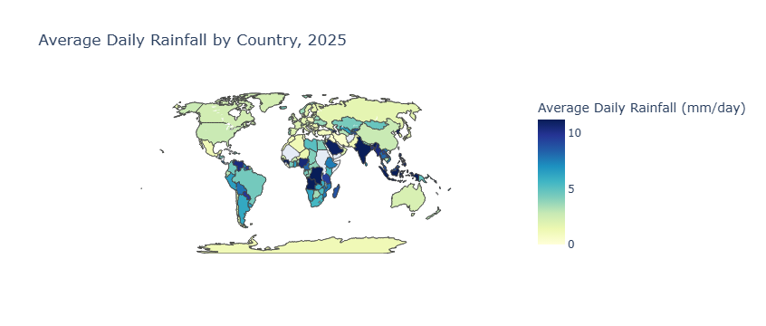

```python
import plotly.express as px
from pyspark.sql.functions import when, lit

# 95th percentile used only to control the visual colour scale
VIS_MAX = percentiles[4]

# Create plotting values.
# The original rainfall value is retained.
rainfall_2025_plot = (
    rainfall_2025_map
    .withColumn(
        "PLOT_RAINFALL_MM",
        when(
            col("AVG_DAILY_RAINFALL_MM") > VIS_MAX,
            lit(VIS_MAX)
        ).otherwise(col("AVG_DAILY_RAINFALL_MM"))
    )
)

# Convert the small country-level dataset to Pandas for Plotly
rainfall_2025_plot_pd = (
    rainfall_2025_plot
    .select(
        "COUNTRY_NAME",
        "ISO3",
        "AVG_DAILY_RAINFALL_MM",
        "PLOT_RAINFALL_MM"
    )
    .toPandas()
)

fig = px.choropleth(
    rainfall_2025_plot_pd,
    locations="ISO3",
    color="PLOT_RAINFALL_MM",
    hover_name="COUNTRY_NAME",
    hover_data={
        "ISO3": True,
        "AVG_DAILY_RAINFALL_MM": ":.2f",
        "PLOT_RAINFALL_MM": False
    },
    locationmode="ISO-3",
    color_continuous_scale="YlGnBu",
    range_color=(0, VIS_MAX),
    title="Average Daily Rainfall by Country, 2025",
    labels={
        "PLOT_RAINFALL_MM": "Average Daily Rainfall (mm/day)",
        "AVG_DAILY_RAINFALL_MM": "Actual Average (mm/day)"
    }
)

fig.update_layout(
    geo=dict(
        showframe=False,
        showcoastlines=True,
        projection_type="natural earth"
    )
)

fig.show()
```

### Improving the map presentation

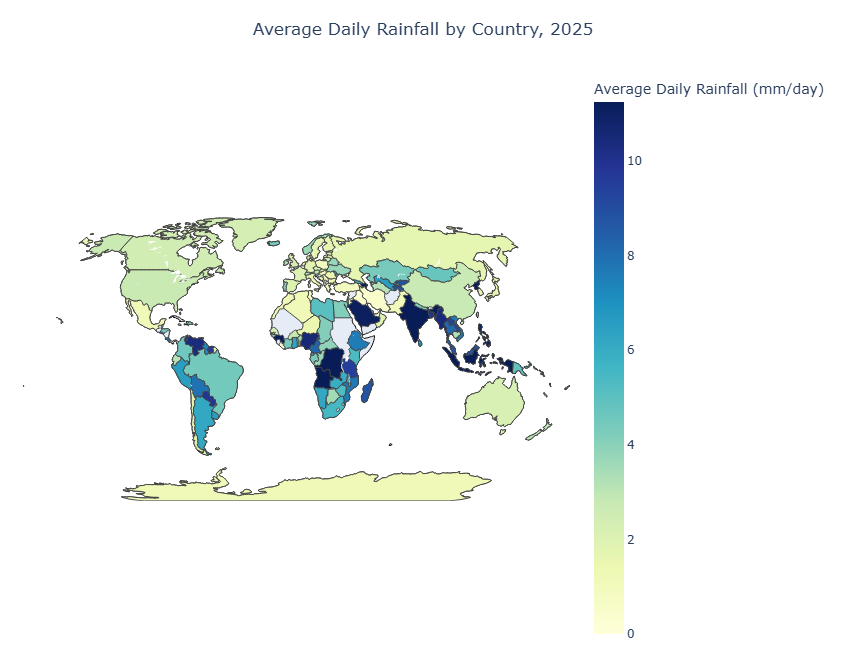

```python
# Improve the presentation of the choropleth

fig.update_layout(
    title={
        "text": "Average Daily Rainfall by Country, 2025",
        "x": 0.5,
        "xanchor": "center"
    },
    width=1200,
    height=650,
    margin=dict(l=20, r=20, t=70, b=20)
)

fig.update_geos(
    projection_type="natural earth",
    showframe=False,
    showcoastlines=True,
    coastlinecolor="black"
)

fig.show()
```

### Finalizing map annotation

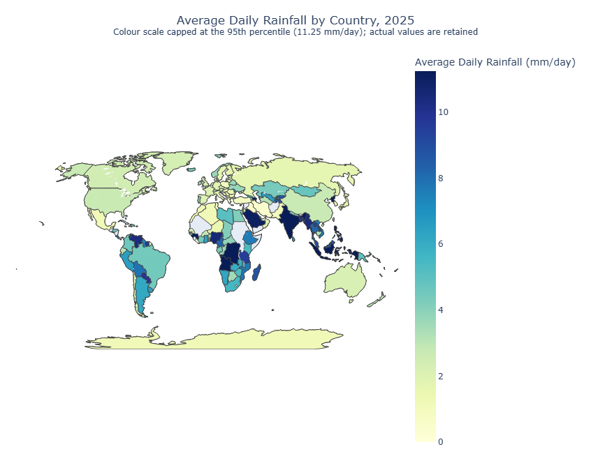

```python
fig.update_layout(
    title={
        "text": (
            "Average Daily Rainfall by Country, 2025"
            "<br><sup>"
            "Colour scale capped at the 95th percentile (11.25 mm/day); "
            "actual values are retained"
            "</sup>"
        ),
        "x": 0.5,
        "xanchor": "center"
    }
)

fig.show()
```

**Report Point**

The 2025 rainfall values were strongly right-skewed, with a median of 3.83 mm/day and a maximum of 54.0 mm/day. To improve visual differentiation among most countries, the choropleth colour scale was capped at the 95th percentile (11.25 mm/day). This was applied only to the visual colour scale, while the original rainfall values were retained. Countries without 2025 observations were treated as missing rather than zero.

### One important interpretation

The map shows that rainfall varies substantially across countries in 2025, with higher average daily rainfall generally visible across parts of South/Southeast Asia, Central Africa and some tropical regions, while much lower values occur across many arid and semi-arid regions.

However, we should be careful about interpreting the map as a direct climate comparison because observation coverage is uneven. Some countries have no 2025 rainfall observations, while some of the high values may be based on relatively few observations.

The Azerbaijan result is a particularly good example: 54 mm/day is the maximum, but the 99th percentile is also 54 mm/day, showing how strongly the distribution is influenced by the extreme upper value.

### Making the hover over information explicit

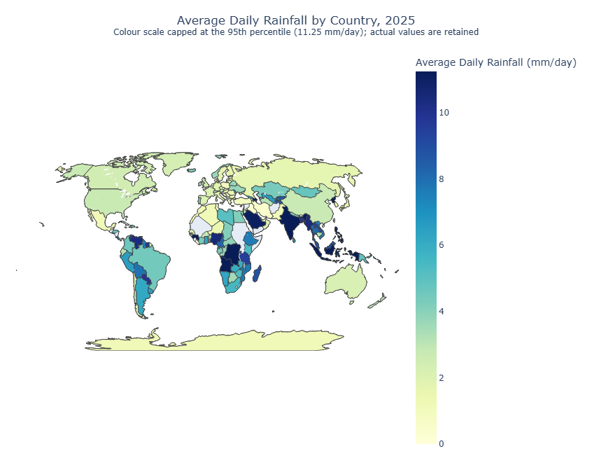

```python
fig.update_traces(
    hovertemplate=(
        "<b>%{hovertext}</b><br>"
        "ISO3: %{customdata[0]}<br>"
        "Actual average rainfall: %{customdata[1]:.2f} mm/day"
        "<extra></extra>"
    ),
    customdata=rainfall_2025_plot_pd[
        ["ISO3", "AVG_DAILY_RAINFALL_MM"]
    ].values
)

fig.show()
```

### Saving the final choropleth

```python
# Save the final interactive choropleth locally

CHOROPLETH_OUTPUT = "rainfall_2025_choropleth.html"

fig.write_html(
    CHOROPLETH_OUTPUT,
    include_plotlyjs=True
)

print("Saved choropleth to:")
print(CHOROPLETH_OUTPUT)
```

```
Saved choropleth to:
rainfall_2025_choropleth.html
```

### Report Interpretation

The choropleth shows the average daily rainfall for 2025 across countries with available observations. ISO3 country codes were used to match the rainfall data with the geographic boundaries. There were 172 country/territory records and all of them could be matched to an ISO3 code. Svalbard and Jan Mayen were excluded from the map because they shared the same SJM code, which could not uniquely represent both locations on the map. This exclusion was only applied to the visualisation and did not change the underlying rainfall data.

The rainfall values were strongly right-skewed. The median average daily rainfall was 3.83 mm/day, while the maximum was 54.0 mm/day for Azerbaijan. To make differences between most countries easier to see, the map colour scale was capped at the 95th percentile of 11.25 mm/day. The actual rainfall values were retained, so this cap only affects the colour representation of the map. Countries with no 2025 observations were treated as missing rather than zero rainfall.

The map shows generally higher rainfall values across several tropical regions, particularly parts of Africa, South and Southeast Asia and South America, while lower values are visible across many drier regions. However, the results should be interpreted with some caution because observation coverage is not consistent between countries. In particular, 47 countries or territories with stations had no rainfall observations available for 2025.

```python
stop_spark()
```

```
26/09/08 15:33:31 WARN ExecutorPodsWatchSnapshotSource: Kubernetes client has been closed.
```

**Spark**

The spark session is **stopped**, confirm that `ama778 (notebook)` is under the completed applications section in the Spark UI.

- [Spark UI](http://mathmadslinux2p.canterbury.ac.nz:8080/)